# **BITCOIN PRICE PREDICTION**

## Table of Contents

1. Introduction
2. Setup
3. Univariate Time Series  
   3.1. Helper Functions  
   3.2. Loading data, visualization  
   3.3. Pre-processing  
   3.4. Experiments  
   3.4.1. Naive Forecast  
   3.4.2. Dense Model (window size = 7)  
   3.4.3. Dense Model (window size = 30)  
   3.4.4. Conv1D  
   3.4.5. LSTM  
   3.4.6. Ensemble
4. Multivariate Time Series  
   4.1. Helper Functions  
   4.2. Making a multivariate Time Series  
   4.4. Pre-processing  
   4.3. Dense (multivariate)
5. Result comparison
6. References

## **1. Introduction**

This project focuses on learning how to work effectively with time series data through the task of predicting Bitcoin's price using deep learning models. Rather than emphasizing model performance, the main goal is to understand and apply essential time series techniques—such as data preparation, windowing, making predictions, and evaluating models properly.

The project is structured in two stages:

Overall, this project serves as a hands-on learning experience for deep learning with time series, providing a foundation for future work on more advanced forecasting problems.

## **2. Setup**

```python
import pandas as pd
import numpy as np
import tensorflow as tf
import matplotlib.pyplot as plt
from tensorflow.keras import layers
import os
from dataclasses import dataclass
from sklearn.preprocessing import minmax_scale
```

```python
import logging
tf.get_logger().setLevel(logging.ERROR)
```

```python
tf.random.set_seed(42)
```

```python
# Class for storing data (for storing some default values)
@dataclass
class G:
    BATCH_SIZE = 32
    WINDOW_SIZE = 7
    HORIZON = 1
```

## **3. Univariate Time Series**

### **3.1. Helper Functions**

#### Plots

```python
def plot_dataframe(dataframe, title, ylabel, figsize=(8, 5)):
    dataframe.plot(figsize=figsize)
    plt.ylabel(ylabel)
    plt.title(title, fontsize=14)
    plt.legend(fontsize=12)


def plot_train_vs_test(X_train, y_train, X_test, y_test, title, ylabel, xlabel, figsize=(8,5)):
    """
    X_train: np_array
    y_train: np_array
    ....
    """
    plt.figure(figsize=figsize)
    plt.scatter(X_train, y_train, s=5, label="Train data")
    plt.scatter(X_test, y_test, s=5, label="Test data")
    plt.title(title)
    plt.xlabel(xlabel)
    plt.ylabel(ylabel)
    plt.legend(fontsize=12)
    plt.show()


# Create a function to plot time series data
def plot_time_series(timesteps, values, format='.', start=0, end=None, label=None):
    """
    Plots a timesteps (a series of points in time) against values (a series of values across timesteps).

    Parameters
    ---------
    timesteps : array of timesteps
    values : array of values across time
    format : style of plot, default "."
    start : where to start the plot (setting a value will index from start of timesteps & values)
    end : where to end the plot (setting a value will index from end of timesteps & values)
    label : label to show on plot of values
    """
    # Plot the series
    plt.plot(timesteps[start:end], values[start:end], format, label=label)
    plt.xlabel("Time")
    plt.ylabel("BTC Price")
    if label:
        plt.legend(fontsize=14) # make label bigger
    plt.grid(True)


    """
    Usage
        plt.figure(figsize=(10, 7))
        plot_time_series(timesteps=X_train, values=y_train, label="Train data")
        plot_time_series(timesteps=X_test, values=y_test, label="Test data")
    """


# y_true vs y_pred
def plot_comparisson(X, y_true, y_pred, title='Prediction Comparison', figsize=(10, 6)):
    """
    Plot true vs predicted values for time series.

    Args:
        X (array-like): Time steps or x-axis values.
        y_true (array-like): True target values.
        y_pred (array-like): Predicted target values.
        title (str): Plot title.
        figsize (tuple): Figure size.

    """
    plt.figure(figsize=figsize)
    plt.plot(X, y_true, label='True', marker='o')
    plt.plot(X, y_pred, label='Predicted', marker='x')
    plt.title(title)
    plt.xlabel('Time step')
    plt.ylabel('Value')
    plt.legend()
    plt.grid(True)
    plt.show()



# plot history
def plot_history(history):
    # Create a figure with two subplots
    plt.figure(figsize=(12, 5))

    # Plot training & validation loss
    plt.subplot(1, 2, 1)  # One row, two columns, first subplot
    plt.plot(history.history['loss'], label='Training Loss ')
    if 'val_loss' in history.history:
        plt.plot(history.history['val_loss'], label='Validation Loss')
    plt.title('Model Loss')
    plt.ylabel('Loss')
    plt.xlabel('Epoch')
    plt.legend(loc='upper right')


    # Adjust layout
    plt.tight_layout()
    plt.show()
```

#### Windowing a dataset

```python
# Create function to label windowed data
def get_labelled_windows(x, horizon=1):
  """
  Creates labels for windowed dataset.

  E.g. if horizon=1 (default)
  Input: [1, 2, 3, 4, 5, 6] -> Output: ([1, 2, 3, 4, 5], [6])
  """
  return x[:, :-horizon], x[:, -horizon:]
```

```python
# Create function to view NumPy arrays as windows
def make_windows(x, window_size=7, horizon=1):
    """
    Turns a 1D array into a 2D array of sequential windows of window_size.
    """
    # 1. Create a window of specific window_size (add the horizon on the end for later labelling)
    window_step = np.expand_dims(np.arange(window_size+horizon), axis=0)
    # print(f"Window step:\n {window_step}")

    # 2. Create a 2D array of multiple window steps (minus 1 to account for 0 indexing)
    window_indexes = window_step + np.expand_dims(np.arange(len(x)-(window_size+horizon-1)), axis=0).T # create 2D array of windows of size window_size
    # print(f"Window indexes:\n {window_indexes[:3], window_indexes[-3:], window_indexes.shape}")

    # 3. Index on the target array (time series) with 2D array of multiple window steps
    windowed_array = x[window_indexes]

    # 4. Get the labelled windows
    windows, labels = get_labelled_windows(windowed_array, horizon=horizon)

    return windows, labels
```

#### Train/Test Split

```python
# Make the train/test splits
def make_train_test_splits(windows, labels, test_split=0.2):
    """
    Splits matching pairs of windows and labels into train and test splits.
    """
    split_size = int(len(windows) * (1-test_split)) # this will default to 80% train/20% test
    train_windows = windows[:split_size]
    train_labels = labels[:split_size]
    test_windows = windows[split_size:]
    test_labels = labels[split_size:]
    return train_windows, test_windows, train_labels, test_labels
```

#### Early Stopping

```python
from tensorflow.keras.callbacks import EarlyStopping

early_stop = EarlyStopping(
    monitor='val_loss',          # Metric to monitor
    mode='min',                  # We want to minimize the loss
    patience=10,                 # Wait 10 epochs for improvement
    restore_best_weights=True   # Roll back to the best model after stopping
)
```

#### Predictions

```python
def make_forecast(model, initial_window, into_future, window_size=G.WINDOW_SIZE, verbose=False) -> np.ndarray:
    future_forecast = []
    last_window = initial_window

    # Get the number of dimensions the model expects (excluding batch)
    expected_input_shape = model.input_shape  # e.g., (None, 30) or (None, 30, 1)
    expected_rank = len(expected_input_shape)

    for step in range(into_future):
        # Reshape last_window based on model type
        if expected_rank == 2:
            model_input = last_window.reshape(1, window_size)  # For Dense models
        elif expected_rank == 3:
            model_input = last_window.reshape(1, window_size, 1)  # For LSTM/CNN models
        else:
            raise ValueError(f"Unsupported model input shape: {expected_input_shape}")

        future_pred = model.predict(model_input, verbose=0)

        if verbose:
            print(f"Step {step+1}: {last_window} -> {tf.squeeze(future_pred).numpy()}")

        future_forecast.append(tf.squeeze(future_pred).numpy())
        last_window = np.append(last_window, future_pred[0][0])[-window_size:]

    return np.array(future_forecast)
```

#### Evaluation

For evaluation and model comparison, we will use a fixed number of time steps (e.g., 50) rather than the entire validation set. This number reflects what we consider a reasonable forecasting horizon before new real data becomes available and the model can be retrained.

While using the full length of the validation set and retraining each model would allow for a more thorough comparison, we avoid this approach due to computational constraints.

In our case, we are particularly interested in short- to medium-term forecasts—for example, predicting the next 30 days of Bitcoin prices—rather than long horizons like 700 days (about 2 years), which are less relevant for our use case.

```python
# MASE implemented courtesy of sktime - https://github.com/alan-turing-institute/sktime/blob/ee7a06843a44f4aaec7582d847e36073a9ab0566/sktime/performance_metrics/forecasting/_functions.py#L16
def mean_absolute_scaled_error(y_true, y_pred):
    """
    Implements MASE (Mean Absolute Scaled Error) for non-seasonal data.
    """
    mae = tf.reduce_mean(tf.abs(y_true - y_pred))
    epsilon = tf.keras.backend.epsilon()
    mae_naive_no_season = tf.reduce_mean(tf.abs(y_true[1:] - y_true[:-1])) + epsilon
    return mae / mae_naive_no_season


# works with any horizon
def evaluate_preds(y_true, y_pred):
    """
    Evaluate forecast predictions using common regression metrics.
    Works with both single-step and multi-step predictions. Automatically
    reduces multi-step metrics to scalars by averaging.

    Parameters:
    - y_true (array-like): Ground truth values (1D or 2D).
    - y_pred (array-like): Predicted values (same shape as y_true).

    Returns:
    - dict: Dictionary with MAE, MSE, RMSE, MAPE, and MASE scores.
    """
    y_true = tf.cast(y_true, dtype=tf.float32)
    y_pred = tf.cast(y_pred, dtype=tf.float32)

    mae = tf.reduce_mean(tf.keras.metrics.mean_absolute_error(y_true, y_pred))
    mse = tf.reduce_mean(tf.keras.metrics.mean_squared_error(y_true, y_pred))
    rmse = tf.sqrt(mse)
    mape = tf.reduce_mean(tf.keras.metrics.mean_absolute_percentage_error(y_true, y_pred))
    mase = tf.reduce_mean(mean_absolute_scaled_error(y_true, y_pred))

    return {
        "mae": mae.numpy(),
        "mse": mse.numpy(),
        "rmse": rmse.numpy(),
        "mape": mape.numpy(),
        "mase": mase.numpy()
    }
```

```python
def pred_eval(model, initial_window, test_labels, X_test, window_size, validation_steps=50, do_plot=True):

    forecast = make_forecast(model, initial_window, validation_steps, window_size)
    results = evaluate_preds(tf.squeeze(test_labels[:validation_steps]), forecast)

    if do_plot:
        plot_comparisson(X_test[-validation_steps:], test_labels[:validation_steps, 0], forecast, model.name, figsize=(8, 5))

    return forecast, results
```

### **3.2. Loading data, visualization**

#### Get data

We're going to get the prices of Bitcoin from 01 October 2013 to 18 May 2021.

```python
# Download Bitcoin historical data from GitHub
# Note: you'll need to select "Raw" to download the data in the correct format
!wget https://raw.githubusercontent.com/mrdbourke/tensorflow-deep-learning/main/extras/BTC_USD_2013-10-01_2021-05-18-CoinDesk.csv
```

```
--2025-07-08 16:46:46--  https://raw.githubusercontent.com/mrdbourke/tensorflow-deep-learning/main/extras/BTC_USD_2013-10-01_2021-05-18-CoinDesk.csv
Resolviendo raw.githubusercontent.com (raw.githubusercontent.com)... 185.199.110.133, 185.199.109.133, 185.199.108.133, ...
Conectando con raw.githubusercontent.com (raw.githubusercontent.com)[185.199.110.133]:443... conectado.
Petición HTTP enviada, esperando respuesta... 200 OK
Longitud: 178509 (174K) [text/plain]
Guardando como: ‘BTC_USD_2013-10-01_2021-05-18-CoinDesk.csv’

BTC_USD_2013-10-01_ 100%[===================>] 174,33K  --.-KB/s    en 0,02s

2025-07-08 16:46:46 (7,41 MB/s) - ‘BTC_USD_2013-10-01_2021-05-18-CoinDesk.csv’ guardado [178509/178509]
```

```python
!ls
```

```
'Bitcoin Price Prediction.ipynb'	      images
 BTC_USD_2013-10-01_2021-05-18-CoinDesk.csv   temporary.ipynb
```

```python
# Parse dates and set date column to index
df = pd.read_csv("BTC_USD_2013-10-01_2021-05-18-CoinDesk.csv",
                 parse_dates=["Date"],
                 index_col=["Date"]) # parse the date column
df.head()
```

| Date | Currency | Closing Price (USD) | 24h Open (USD) | 24h High (USD) | 24h Low (USD) |
| --- | --- | --- | --- | --- | --- |
| 2013-10-01 | BTC | 123.65499 | 124.30466 | 124.75166 | 122.56349 |
| 2013-10-02 | BTC | 125.45500 | 123.65499 | 125.75850 | 123.63383 |
| 2013-10-03 | BTC | 108.58483 | 125.45500 | 125.66566 | 83.32833 |
| 2013-10-04 | BTC | 118.67466 | 108.58483 | 118.67500 | 107.05816 |
| 2013-10-05 | BTC | 121.33866 | 118.67466 | 121.93633 | 118.00566 |

```python
df.info()
```

```
<class 'pandas.core.frame.DataFrame'>
DatetimeIndex: 2787 entries, 2013-10-01 to 2021-05-18
Data columns (total 5 columns):
 #   Column               Non-Null Count  Dtype
---  ------               --------------  -----
 0   Currency             2787 non-null   object
 1   Closing Price (USD)  2787 non-null   float64
 2   24h Open (USD)       2787 non-null   float64
 3   24h High (USD)       2787 non-null   float64
 4   24h Low (USD)        2787 non-null   float64
dtypes: float64(4), object(1)
memory usage: 130.6+ KB
```

There are no missing values and the index is a DateTimeIndex (ideal for time series analysis).

In this first part, we will keep only the date index and the closing price.

```python
# Only keep closing price for each day
bitcoin_prices = pd.DataFrame(df["Closing Price (USD)"]).rename(columns={"Closing Price (USD)": "Price"})
bitcoin_prices.head(3)
```

| Date | Price |
| --- | --- |
| 2013-10-01 | 123.65499 |
| 2013-10-02 | 125.45500 |
| 2013-10-03 | 108.58483 |

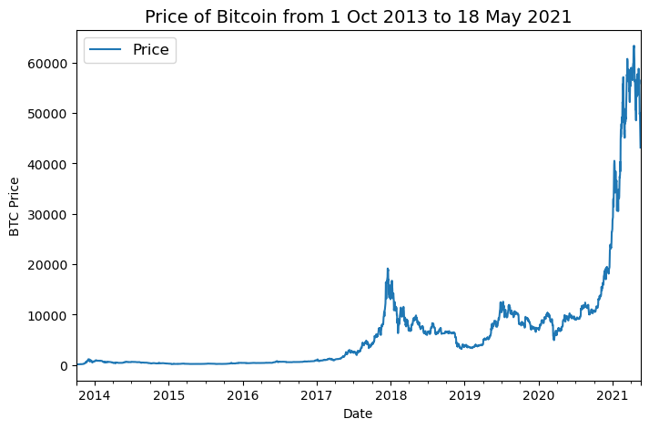

```python
plot_dataframe(bitcoin_prices, "Price of Bitcoin from 1 Oct 2013 to 18 May 2021", "BTC Price")
```

#### Train/Test Split

First, let's turn our DataFrame index and column into NumPy arrays.

```python
# Get bitcoin date array
timesteps = bitcoin_prices.index.to_numpy()
prices = bitcoin_prices["Price"].to_numpy()

timesteps[:5], prices[:3]
```

```
(array(['2013-10-01T00:00:00.000000000', '2013-10-02T00:00:00.000000000',
        '2013-10-03T00:00:00.000000000', '2013-10-04T00:00:00.000000000',
        '2013-10-05T00:00:00.000000000'], dtype='datetime64[ns]'),
 array([123.65, 125.45, 108.58]))
```

```python
# Create train and test splits the right way for time series data
split_size = int(0.8 * len(prices)) # 80% train, 20% test

# Create train data splits (everything before the split)
X_train, y_train = timesteps[:split_size], prices[:split_size]

# Create test data splits (everything after the split)
X_test, y_test = timesteps[split_size:], prices[split_size:]

len(X_train), len(X_test), len(y_train), len(y_test)
```

```
(2229, 558, 2229, 558)
```

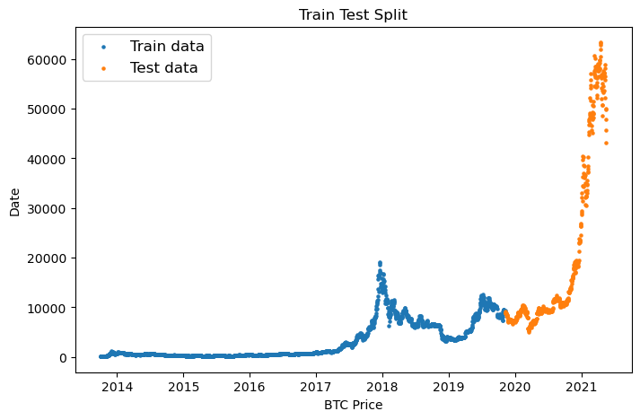

```python
plot_train_vs_test(X_train, y_train, X_test, y_test, 'Train Test Split', 'Date', 'BTC Price')
```

We'll use the training set (past data) to train our model and evaluate its performance on the test set, which represents a simulated future.

It's important to understand that the test set is not the real future—it's a pseudofuture created from historical data. Its purpose is to give us an indication of how well our model might perform when making predictions on unseen, real future data.

By evaluating performance on this pseudofuture, we can identify issues, tune our model, and build confidence in its generalization ability—before deploying it in real-world scenarios.

### **3.3. Pre-processing**

Since most models require different input data (e.g., due to different window sizes or horizons), we will perform the preprocessing immediately before building the model.

### **3.4. Experiments**

We will conduct the following experiments:

| Model Number | Model Type | Horizon size | Window size |
| --- | --- | --- | --- |
| 0 | Naïve model (baseline) | NA | NA |
| 1 | Dense model | 1 | 7 |
| 2 | Dense model | 1 | 30 |
| 4 | Conv1D | 1 | 7 |
| 5 | LSTM | 1 | 60 |
| 6 | Ensemble (multiple models optimized on different loss functions) | 1 | 7 |
| 7 | Dense Model (Multivariate data) | 1 | 7 |

```python
forecast_horizon = 30
```

#### **3.4.1. Model 0 (Baseline) : Naive Forecast**

**Naive Forecast**

$$\hat{y}_{t} = y_{t-1}$$

```python
# Create a naïve forecast
naive_forecast = y_test[:-1] # Naïve forecast equals every value excluding the last value
naive_forecast[:3], naive_forecast[-3:] # View first 3 and last 3
```

```
(array([9226.49, 8794.36, 8798.04]), array([50032.69, 47885.63, 45604.62]))
```

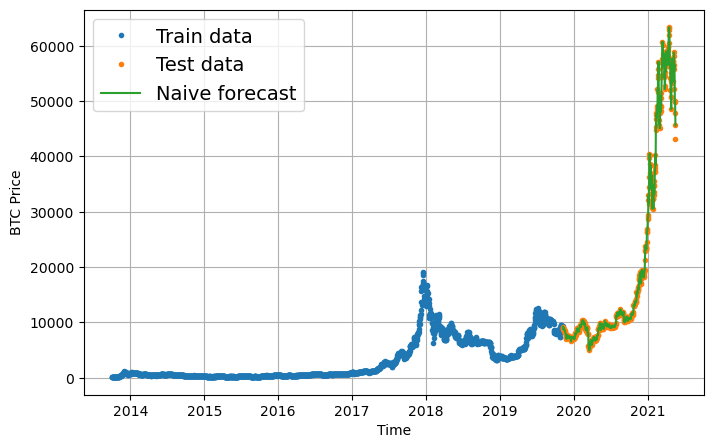

```python
# Plot naive forecast
plt.figure(figsize=(8, 5))
plot_time_series(timesteps=X_train, values=y_train, label="Train data")
plot_time_series(timesteps=X_test, values=y_test, label="Test data")
plot_time_series(timesteps=X_test[1:], values=naive_forecast, format="-", label="Naive forecast");
```

Let's zoom in to take a better look.

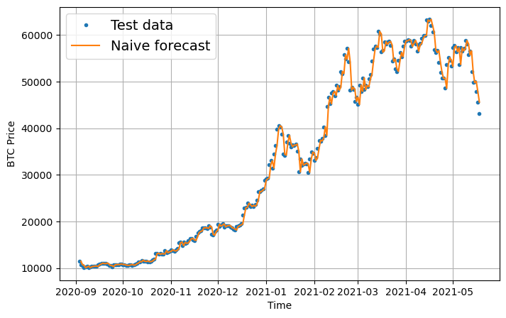

```python
plt.figure(figsize=(8, 5))
offset = 300 # offset the values by 300 timesteps
plot_time_series(timesteps=X_test, values=y_test, start=offset, label="Test data")
plot_time_series(timesteps=X_test[1:], values=naive_forecast, format="-", start=offset, label="Naive forecast");
```

We see the naïve forecast comes slightly after the test data. This makes sense because the naive forecast uses the previous timestep value to predict the next timestep value.

```python
naive_results = evaluate_preds(y_true=y_test[1:forecast_horizon+1],
                               y_pred=naive_forecast[:forecast_horizon])
naive_results
```

```
{'mae': 166.84868,
 'mse': 46829.707,
 'rmse': 216.40173,
 'mape': 2.126316,
 'mase': 1.0580055}
```

Taking a look at the naïve forecast's MAE, it seems on average each forecast is ~$167 different than the actual Bitcoin price.

How does this compare to the average price of Bitcoin in the test dataset?

```python
# Find average price of Bitcoin in test dataset
avg_price_test = tf.reduce_mean(y_test).numpy()
avg_price_test
```

```
20056.632963737226
```

```python
relative_MAE = naive_results['mae']/avg_price_test
relative_MAE
```

```
0.008318877794220634
```

**Results**

- MAE (Mean Absolute Error): ~166
- Mean of y_test: ~20,057
- Relative MAE: 0.8%

**Interpretation**

An average error of 166 on a value around 20,000 indicates reasonable absolute accuracy, but since Bitcoin price fluctuates heavily, the MAE alone may be misleading:

- For low-volatility periods, this error could be large.
- For high-volatility periods, it might be small in comparison.

**Warning**

In volatile series like Bitcoin, relative metrics such as MAPE (Mean Absolute Percentage Error) or normalized RMSE often give better context.

#### **3.4.2. Dense Model (window=7, horizon=1)**

#### Pre-processing

```python
window_size = 7
horizon = 1
```

```python
# windowing
full_windows_1, full_labels_1 = make_windows(prices, window_size=window_size, horizon=horizon)
len(full_windows_1), len(full_labels_1)
```

```
(2780, 2780)
```

```python
# View the first 3 windows/labels
for i in range(3):
  print(f"Window: {full_windows_1[i]} -> Label: {full_labels_1[i]}")
```

```
Window: [123.65 125.45 108.58 118.67 121.34 120.66 121.8 ] -> Label: [123.03]
Window: [125.45 108.58 118.67 121.34 120.66 121.8  123.03] -> Label: [124.05]
Window: [108.58 118.67 121.34 120.66 121.8  123.03 124.05] -> Label: [125.96]
```

```python
# View the last 3 windows/labels
for i in range(3):
  print(f"Window: {full_windows_1[i-3]} -> Label: {full_labels_1[i-3]}")
```

```
Window: [58788.21 58102.19 55715.55 56573.56 52147.82 49764.13 50032.69] -> Label: [47885.63]
Window: [58102.19 55715.55 56573.56 52147.82 49764.13 50032.69 47885.63] -> Label: [45604.62]
Window: [55715.55 56573.56 52147.82 49764.13 50032.69 47885.63 45604.62] -> Label: [43144.47]
```

```python
# Train/Test Split
train_windows_1, test_windows_1, train_labels_1, test_labels_1 = make_train_test_splits(full_windows_1, full_labels_1)
train_windows_1[:3], train_labels_1[:3]
```

```
(array([[123.65, 125.45, 108.58, 118.67, 121.34, 120.66, 121.8 ],
        [125.45, 108.58, 118.67, 121.34, 120.66, 121.8 , 123.03],
        [108.58, 118.67, 121.34, 120.66, 121.8 , 123.03, 124.05]]),
 array([[123.03],
        [124.05],
        [125.96]]))
```

```python
# Check to see if same (accounting for horizon and window size)
np.array_equal(np.squeeze(train_labels_1[:-G.HORIZON-1]), y_train[G.WINDOW_SIZE:])
```

```
True
```

#### Build, compile and fit the model

```python
def build_compile_model_one(name, horizon=1, dropout_rate=0.1):
    model = tf.keras.Sequential([
        layers.Dense(32, activation="relu"),
        layers.Dropout(dropout_rate),
        layers.Dense(32, activation="relu"),
        layers.Dropout(dropout_rate),
        layers.Dense(horizon, activation="linear")  # output layer
    ], name=name)

    optimizer = tf.keras.optimizers.Adam(learning_rate=1e-4)

    model.compile(
        loss="mae",
        optimizer=optimizer,
        metrics=["mae"]
    )

    return model

# Example use
model_1 = build_compile_model_one("model_1_dense_improved", horizon=1)
```

```python
# Fit model
history_1 = model_1.fit(
    x=train_windows_1,
    y=train_labels_1,
    epochs=100,
    verbose=0,
    batch_size=G.BATCH_SIZE,
    validation_data=(test_windows_1, test_labels_1),
    callbacks=[early_stop]
)
```

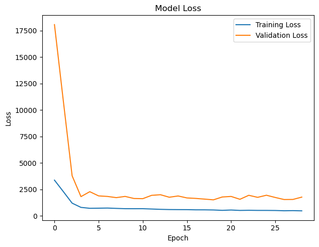

```python
plot_history(history_1)
```

#### Predictions and evaluation

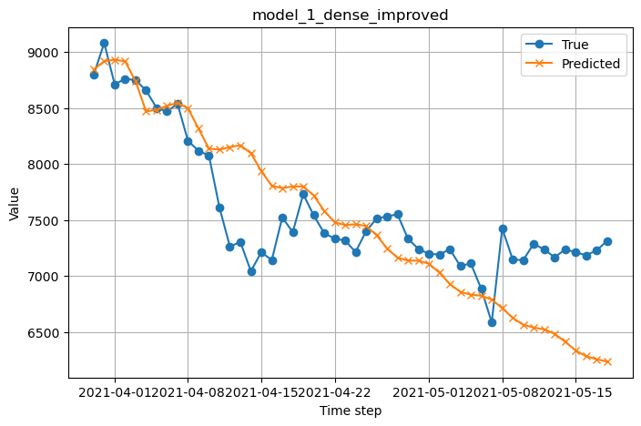

```python
forecast_1, results_1 = pred_eval(model_1, test_windows_1[0], test_labels_1, X_test, window_size)
```

```python
results_1
```

```
{'mae': 377.7437,
 'mse': 243775.2,
 'rmse': 493.73596,
 'mape': 5.1510525,
 'mase': 2.5208793}
```

#### Analysis

| Metric | Value | Interpretation |
| --- | --- | --- |
| **MAE** | 378 | Average error around **$378**, indicating reasonably close predictions to actual values. |
| **RMSE** | 494 | RMSE higher than MAE → some larger errors are present but overall errors remain moderate. |
| **MAPE** | 5.15% | Predictions are off by **about 5% on average** — showing fairly good accuracy. |
| **MASE** | 2.52 | The model performs **~2.5× worse than a naive forecast**, indicating there is still room for improvement. |

This model shows good initial performance but leaves space to enhance accuracy further.

#### **3.4.3. Dense Model (window=30, horizon=1)**

Now, we will try a larger window size. Because of that, we need to adjust the data for the new model.

#### Pre-processing

```python
window_size = 30 # use 30 timesteps in the past
horizon = 1 # predict one step at a time
```

```python
# Make windowed data with appropriate horizon and window sizes
full_windows_2, full_labels_2 = make_windows(prices, window_size=window_size, horizon=horizon)
len(full_windows_2), len(full_labels_2)
```

```
(2757, 2757)
```

```python
# Make train and testing windows
train_windows_2, test_windows_2, train_labels_2, test_labels_2 = make_train_test_splits(windows=full_windows_2,
                                                                                        labels=full_labels_2)
train_windows_2.shape, train_labels_2.shape, test_windows_2.shape, test_labels_2.shape
```

```
((2205, 30), (2205, 1), (552, 30), (552, 1))
```

#### Build, compile and fit the model

```python
def build_compile_model_two(name, horizon=1, dropout_rate=0.1):
    model = tf.keras.Sequential([
        layers.Dense(32, activation="relu"),
        layers.Dropout(dropout_rate),
        layers.Dense(32, activation="relu"),
        layers.Dropout(dropout_rate),
        layers.Dense(horizon, activation="linear")  # output layer
    ], name=name)

    optimizer = tf.keras.optimizers.Adam(learning_rate=1e-4)

    model.compile(
        loss="mae",
        optimizer=optimizer,
        metrics=["mae"]
    )

    return model

# Example use
model_2 = build_compile_model_two("model_2_dense_larger_window", horizon=1)
```

```python
# fit
history_2 = model_2.fit(train_windows_2,
            train_labels_2,
            epochs=50,
            batch_size=G.BATCH_SIZE,
            verbose=0,
            validation_data=(test_windows_2, test_labels_2),
            callbacks=[early_stop])
```

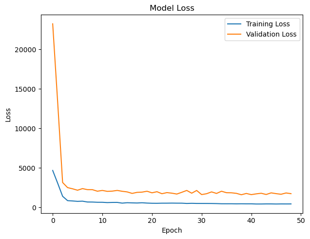

```python
plot_history(history_2)
```

#### Predictions and evaluation

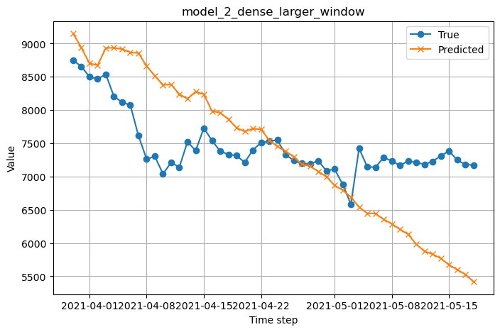

```python
forecast_2, results_2 = pred_eval(model_2, test_windows_2[0], test_labels_2, X_test, window_size)
```

Let's see how it performs when we try to predict a time equal to the total length of the validation set.

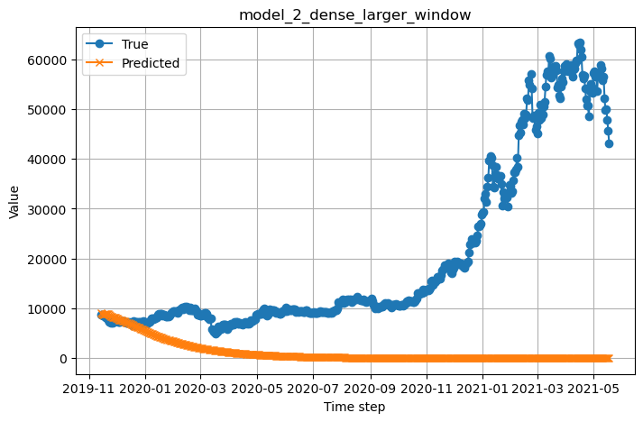

```python
forecast_2_complete, results_2_complete = pred_eval(model_2, test_windows_2[0], test_labels_2, X_test,
                                                    window_size, len(test_labels_2))
```

It can be clearly seen that the further out we try to predict, the worse the predictions are.

```python
results_2
```

```
{'mae': 713.8421,
 'mse': 784598.9,
 'rmse': 885.7759,
 'mape': 9.688037,
 'mase': 5.0593767}
```

#### Analysis

| Metric | Value | Interpretation |
| --- | --- | --- |
| **MAE** | 714 | Average error about **$714**, indicating moderate deviation from actual values. |
| **RMSE** | 886 | RMSE higher than MAE → presence of some larger errors, but errors remain moderate overall. |
| **MAPE** | 9.69% | Predictions are off by **nearly 10% on average** — reasonable but not highly accurate. |
| **MASE** | 5.06 | Model performs **~5× worse than a naive forecast** — there is a significant room for improvement. |

This model shows moderate accuracy but still requires improvement to be reliably useful.

#### **3.4.4. Conv1D (Window size = 7)**

Conv1D models can be used for seq2seq (sequence to sequence) problems.

In our case, the input sequence is the previous 7 (window size) days of Bitcoin price data and the output is the next day (in seq2seq terms this is called a many to one problem).

[figure not shown]

*Framing Bitcoin forecasting in seq2seq (sequence to sequence) terms. Using a window size greater than 1 and a horizon of one results in a many to one problem. Using a window size of >1 and a horizon of >1 results in a many to many problem.

Before we build a Conv1D model, let's recreate our datasets.

#### Pre-processing

```python
horizon = 1 # predict next day
window_size = 7 # use previous week worth of data
```

```python
# Create windowed dataset
full_windows_3, full_labels_3 = make_windows(prices, window_size=window_size, horizon=horizon)
len(full_windows_3), len(full_labels_3)
```

```
(2780, 2780)
```

```python
# Create train/test splits
train_windows_3, test_windows_3, train_labels_3, test_labels_3 = make_train_test_splits(full_windows_3,
                                                                                        full_labels_3)
len(train_windows_3), len(test_windows_3), len(train_labels_3), len(test_labels_3)
```

```
(2224, 556, 2224, 556)
```

Now, since we're going to be using Conv1D layers, we need to make sure our input shapes are correct.

The Conv1D layer in TensorFlow takes an input of: (batch_size, timesteps, input_dim).

In our case:

- The batch_size is handled automatically.
- timesteps = WINDOW_SIZE -> our model will view WINDOW_SIZE (one week) worth of past data at a time.
- input_dim = num_features -> the number of features in each timestep (e.g., temperature, humidity, etc.). In our case will be 1.

Currently, our data has the correct timesteps dimension, but we need to ensure it includes the appropriate input_dim.

```python
# Check data sample shapes
train_windows_3[0].shape # returns (WINDOW_SIZE, )
```

```
(7,)
```

To fix this, we could adjust the shape of all of our `train_windows` or we could use a [`tf.keras.layers.Lamdba`](https://keras.io/api/layers/core_layers/lambda/) (called a Lambda layer) to do this for us in our model.

The Lambda layer wraps a function into a layer which can be used with a model.

```python
# Before we pass our data to the Conv1D layer, we have to reshape it in order to make sure it works
x = tf.constant(train_windows_3[0])
expand_dims_layer = layers.Lambda(lambda x: tf.expand_dims(x, axis=1)) # add an extra dimension
print(f"Original shape: {x.shape}") # (WINDOW_SIZE)
print(f"Original values: {x}")
print(f"Expanded shape: {expand_dims_layer(x).shape}") # (WINDOW_SIZE, input_dim)
print(f"Original values with expanded shape:\n {expand_dims_layer(x)}")
```

```
Original shape: (7,)
Original values: [123.65 125.45 108.58 118.67 121.34 120.66 121.8 ]
Expanded shape: (7, 1)
Original values with expanded shape:
 [[123.65]
 [125.46]
 [108.58]
 [118.67]
 [121.34]
 [120.66]
 [121.79]]
```

#### Build, compile and fit the model

```python
def build_compile_model_3(name, horizon):
    # Create model
    model = tf.keras.Sequential([
        # Create Lambda layer to reshape inputs, without this layer, the model will error
        layers.Lambda(lambda x: tf.expand_dims(x, axis=1)), # resize the inputs to adjust for window size / Conv1D 3D input requirements
        layers.Conv1D(filters=128, kernel_size=5, padding="causal", activation="relu"),
        layers.Dense(horizon)
    ], name=name)

    optimizer = tf.keras.optimizers.Adam(learning_rate=1e-4)

    # Compile model
    model.compile(loss="mae",
                  optimizer=optimizer,
                  metrics=["mae"]
                 )


    return model


model_3 = build_compile_model_3('model_3_conv1D', horizon)
```

```python
# fit
history_3 = model_3.fit(train_windows_3,
            train_labels_3,
            batch_size=G.BATCH_SIZE,
            epochs=50,
            verbose=0,
            validation_data=(test_windows_3, test_labels_3),
            callbacks=[early_stop])
```

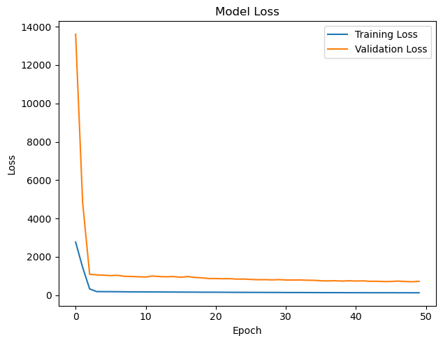

```python
plot_history(history_3)
```

#### Predictions and evaluations

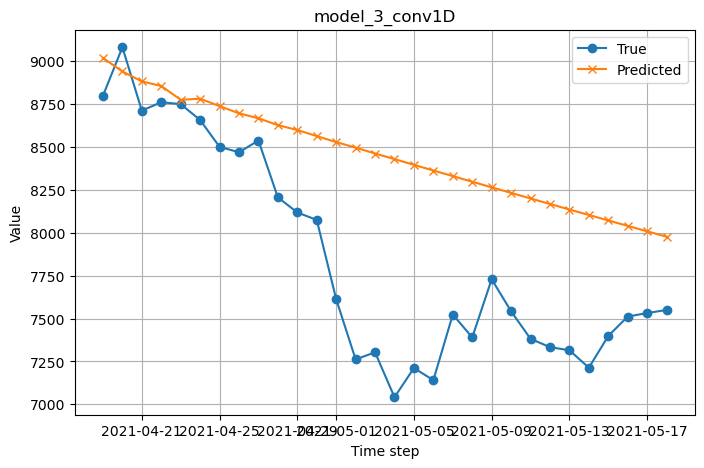

```python
forecast_3, results_3 = pred_eval(model_3, test_windows_3[0], test_labels_3, X_test, window_size, forecast_horizon)
```

```python
results_3
```

```
{'mae': 608.90344,
 'mse': 520787.06,
 'rmse': 721.65576,
 'mape': 8.140013,
 'mase': 3.848976}
```

#### Analysis

| Metric | Value | Interpretation |
| --- | --- | --- |
| **MAE** | 609 | Average error about **$609**, indicating moderate prediction accuracy. |
| **RMSE** | 722 | RMSE slightly higher than MAE → some larger errors still exist, but overall errors are controlled. |
| **MAPE** | 8.14% | Predictions are off by **about 8% on average** — showing moderate accuracy. |
| **MASE** | 3.85 | Model performs **~3.8× worse than a naive forecast** — with room to improve. |

This model shows decent performance and is a positive step, though further refinement is needed for more reliable predictions.

#### **3.4.5. LSTM**

```python
horizon = 1
window_size = 60
```

```python
# Create windowed dataset
full_windows_4, full_labels_4 = make_windows(prices, window_size=window_size, horizon=horizon)
len(full_windows_4), len(full_labels_4)
```

```
(2727, 2727)
```

```python
# Create train/test splits
train_windows_4, test_windows_4, train_labels_4, test_labels_4 = make_train_test_splits(full_windows_4,
                                                                                        full_labels_4)
len(train_windows_4), len(test_windows_4), len(train_labels_4), len(test_labels_4)
```

```
(2181, 546, 2181, 546)
```

#### Build, compile and fit the model

```python
def build_compile_model_4(name, window_size=window_size, horizon=horizon):
    inputs = layers.Input(shape=(window_size))
    x = layers.Lambda(lambda x: tf.expand_dims(x, axis=1))(inputs)
        # expand input dimension to be compatible with LSTM
    x = layers.LSTM(64, activation='relu')(x)
    output = layers.Dense(horizon)(x)
    model = tf.keras.Model(inputs=inputs, outputs=output, name=name)

    optimizer = tf.keras.optimizers.Adam(learning_rate=1e-4)

    model.compile(loss='mae',
                  optimizer=optimizer,
                  metrics=["mae"]
                 )

    return model



model_4 = build_compile_model_4('model_4_lstm')
```

```python
# fit
history_4 = model_4.fit(train_windows_4,
            train_labels_4,
            epochs=50, # 30
            verbose=0,
            batch_size=G.BATCH_SIZE,
            validation_data=(test_windows_4, test_labels_4),
            callbacks=[early_stop])
```

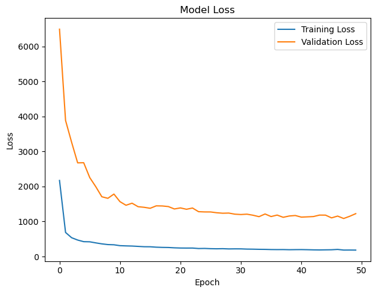

```python
plot_history(history_4)
```

#### Predictions and Evaluation

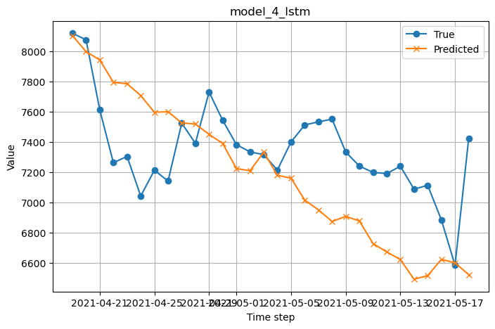

```python
forecast_4, results_4 = pred_eval(model_4, test_windows_4[0], test_labels_4, X_test, window_size, forecast_horizon)
```

```python
results_4
```

```
{'mae': 353.35587,
 'mse': 182243.6,
 'rmse': 426.9,
 'mape': 4.838035,
 'mase': 2.0244167}
```

#### Analysis

| Metric | Value | Interpretation |
| --- | --- | --- |
| **MAE** | 353 | Average error about **$353**, indicating fairly close predictions to actual values. |
| **RMSE** | 427 | RMSE higher than MAE → some larger errors exist but overall prediction errors are moderate. |
| **MAPE** | 4.84% | Predictions are off by **under 5% on average** — showing good accuracy. |
| **MASE** | 2.02 | Model performs **~2× worse than a naive forecast** — a reasonable level, with room for improvement. |

This model shows good initial accuracy and is a solid foundation for further improvements.

#### **3.4.6. Ensemble**

An **ensemble** involves training and combining multiple different models to solve the same problem.

For example, we can ensemble models that differ in:

- Loss functions (e.g., `MASE`, `MAPE`, `MAE`)
- Input window sizes (e.g., 7, 30 days)
- Random initialization (e.g., different seeds in neural networks)

The benefit of ensembling is that you get a **"wisdom of the crowd"** effect. Instead of relying on a single model’s predictions, you aggregate the outputs—often by taking the **mean** or **median**—to get more stable and often more accurate forecasts.

The key idea is **diversity**: ensembling only helps when the models bring different perspectives or behaviors.  
It wouldn’t make sense to train the exact same model 10 times on the same data and average their predictions—unless there's a source of randomness that causes the models to diverge.

Fortunately, in deep learning, **randomness is built in**. Even with the same architecture and data, models can learn differently due to (for example]):

- Random initial weights and biases
- Stochastic optimization (e.g., **stochastic gradient descent**, or SGD)

Each model starts with a random configuration and learns through a process that includes randomness (e.g., data shuffling, dropout, noisy gradients), which leads to variations in the final model.

**Our Ensemble Strategy**

In our case, we’ll build an ensemble using:

- Different **loss functions** (`MAE`, `MSE`, `MAPE`, etc.)
- Multiple **randomly initialized models** (same architecture, different runs)

This way, we create a **diverse set of models**, all trying to capture the underlying data dynamics, and combine their predictions for a more robust result.

#### Pre-processing

```python
horizon = 1
window_size = 7
```

```python
full_windows_5, full_labels_5 = make_windows(prices, window_size=window_size, horizon=horizon)
train_windows_5, test_windows_5, train_labels_5, test_labels_5 = make_train_test_splits(full_windows_5, full_labels_5)
```

```python
# Build a simple model
def build_model(horizon, loss_fn):
    """
    Builds and compiles a simple feedforward model for forecasting.

    Parameters:
        horizon (int): Number of future time steps to predict.
        loss_fn (str): Loss function to use for training.

    Returns:
        tf.keras.Model: A compiled Keras model.
    """
    model = tf.keras.Sequential([
        layers.Dense(128, kernel_initializer="he_normal", activation="relu"),
        layers.Dense(128, kernel_initializer="he_normal", activation="relu"),
        layers.Dense(horizon)
    ])

    model.compile(
        loss=loss_fn,
        optimizer=tf.keras.optimizers.Adam(learning_rate=1e-4),
        metrics=["mae", "mse"]
    )

    return model
```

```python
def get_ensemble_models(horizon,
                        train_windows,
                        test_windows,
                        train_labels,
                        test_labels,
                        num_iter=10,
                        num_epochs=10,
                        loss_fns=["mae", "mse", "mape"]):
    """
    Trains an ensemble of neural network models using different loss functions and random initializations.

    Each model in the ensemble is trained on the same data but may differ in:
    - The loss function used (from the provided `loss_fns` list)
    - The random weight initialization (due to non-deterministic training)

    Parameters:
        horizon (int): Number of time steps the model should predict.
        train_windows (array-like): Input training sequences.
        test_windows (array-like): Input validation sequences.
        train_labels (array-like): Ground truth labels for training.
        test_labels (array-like): Ground truth labels for validation.
        num_iter (int): Number of models to train per loss function (for randomization).
        num_epochs (int): Maximum number of training epochs for each model.
        loss_fns (list of str): Loss functions to use for training different models.

    Returns:
        list: A list of trained Keras models forming the ensemble.
    """

    ensemble_models = []

    # Train num_iter models for each loss function
    for i in range(num_iter):
        for loss_fn in loss_fns:
            print(f"Training model #{i} with loss: {loss_fn}")

            # Build and compile a model using the selected loss function
            model = build_model(horizon, loss_fn)

            # Train the model with early stopping and learning rate scheduling
            model.fit(train_windows,
                      train_labels,
                      epochs=num_epochs,
                      verbose=0,
                      validation_data=(test_windows, test_labels),
                      callbacks=[
                          tf.keras.callbacks.EarlyStopping(
                              monitor="val_loss",      # Stop if validation loss doesn't improve
                              patience=5,
                              restore_best_weights=True
                          ),
                          tf.keras.callbacks.ReduceLROnPlateau(
                              monitor="val_loss",      # Reduce learning rate if stuck
                              patience=100,
                              verbose=1
                          )
                      ])

            # Add the trained model to the ensemble
            ensemble_models.append(model)

    return ensemble_models  # Return the full list of trained models
```

Let's try it out by running `num_iter=5` runs for 20 epochs. This will result in 15 total models (5 for each of the 3 different loss functions).

```python
%%time
# Get list of trained ensemble models
ensemble_models = get_ensemble_models(horizon,
                                      train_windows_5,
                                      test_windows_5,
                                      train_labels_5,
                                      test_labels_5,
                                      num_iter=5,
                                      num_epochs=20)
```

```
Training model #0 with loss: mae
Training model #0 with loss: mse
Training model #0 with loss: mape
Training model #1 with loss: mae
Training model #1 with loss: mse
Training model #1 with loss: mape
Training model #2 with loss: mae
Training model #2 with loss: mse
Training model #2 with loss: mape
Training model #3 with loss: mae
Training model #3 with loss: mse
Training model #3 with loss: mape
Training model #4 with loss: mae
Training model #4 with loss: mse
Training model #4 with loss: mape
CPU times: user 51.1 s, sys: 2.29 s, total: 53.4 s
Wall time: 41.7 s
```

#### Predictions

```python
def make_ensemble_preds(ensemble_models, num_pred, initial_window, window_size=window_size):
    """
    Generates future forecasts from each model in the ensemble.

    Parameters:
        ensemble_models (list): List of trained Keras models.
        num_pred (int): Number of time steps to predict into the future.
        initial_window (array-like): Initial input window to begin forecasting.
        window_size (int): Size of the input window for each prediction step.

    Returns:
        tf.Tensor: Tensor of shape (n_models, num_pred) with predictions from each model.
    """
    ensemble_preds = []

    for model in ensemble_models:
        # Predict into the future using the current model
        preds = make_forecast(
            model=model,
            initial_window=initial_window,
            into_future=num_pred,
            window_size=window_size,  # use parameter, not global
            verbose=False
        )
        ensemble_preds.append(preds)

    # Convert list to Tensor and remove extra dimensions if needed
    return tf.constant(tf.squeeze(ensemble_preds))
```

```python
model_5_preds = make_ensemble_preds(ensemble_models, forecast_horizon, test_windows_5[0])
```

```python
# Aggregate ensemble predictions using the median across models
ensemble_forecast = np.median(model_5_preds, axis=0)

# Evaluate against the true future values
ensemble_results = evaluate_preds(y_true=test_labels_5[:forecast_horizon, 0], y_pred=ensemble_forecast)
ensemble_results
```

```
{'mae': 346.4694,
 'mse': 215808.05,
 'rmse': 464.55145,
 'mape': 4.6375113,
 'mase': 2.1900883}
```

```python
model_5_preds.shape # 30 preds for each of the 15 models
```

```
TensorShape([15, 30])
```

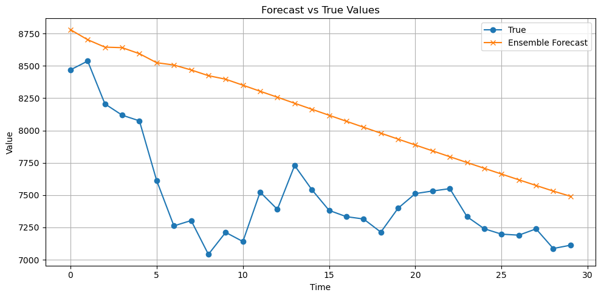

```python
# Select the range
true_vals = test_labels_5[window_size : forecast_horizon + window_size]
pred_vals = ensemble_forecast

# Plot
plt.figure(figsize=(10, 5))
plt.plot(true_vals, label='True', marker='o')
plt.plot(pred_vals, label='Ensemble Forecast', marker='x')
plt.title("Forecast vs True Values")
plt.xlabel("Time")
plt.ylabel("Value")
plt.legend()
plt.grid(True)
plt.tight_layout()
plt.show()
```

#### Analysis

| Metric | Value | Interpretation |
| --- | --- | --- |
| **MAE** | 346 | Average error about **$346**, indicating fairly close predictions to actual values. |
| **RMSE** | 465 | RMSE higher than MAE → some larger errors exist but overall errors remain moderate. |
| **MAPE** | 4.64% | Predictions are off by **under 5% on average** — showing good accuracy. |
| **MASE** | 2.19 | Model performs **~2.2× worse than a naive forecast** — reasonable given current constraints. |

This result is from an ensemble trained under computational constraints — few models, trained for few epochs. With more resources, much better results could be achievable.

## **4. Multivariate Time Series**

Let's see if adding features helps us get better results.

This feature will vary depending on the time series you're working with. In our case, we can explore whether the Bitcoin block reward size adds any predictive value to our models.

The block reward size refers to the amount of Bitcoin awarded to miners for successfully adding a new block to the blockchain. It halves approximately every four years and could influence market behavior due to changes in supply dynamics.

Let's encode this information into our time series dataset and evaluate whether it improves model performance.

### **4.1. Helper Functions**

#### Plots

```python
# Plot the block reward/price over time
# Note: Because of the different scales of our values we'll scale them to be between 0 and 1.
def plot_time_series_multivar(df):
    """
    args: df with price and block_reward
    """
    scaled_df = pd.DataFrame(minmax_scale(df[["Price", "block_reward"]]), # we need to scale the data first
                                     columns=df.columns,
                                     index=df.index)
    scaled_df.plot(figsize=(8, 5));


# plot history
def plot_history_multivar(history):

    # Create subplots
    fig, (ax1, ax2) = plt.subplots(1, 2, figsize=(12, 5))

    # Plot MAE
    ax1.plot(history.history['mae'], label='Train MAE')
    ax1.plot(history.history['val_mae'], label='Validation MAE')
    ax1.set_title('Mean Absolute Error (MAE)')
    ax1.set_xlabel('Epoch')
    ax1.set_ylabel('MAE')
    ax1.legend()

    # Plot MSE
    ax2.plot(history.history['mse'], label='Train MSE')
    ax2.plot(history.history['val_mse'], label='Validation MSE')
    ax2.set_title('Mean Squared Error (MSE)')
    ax2.set_xlabel('Epoch')
    ax2.set_ylabel('MSE')
    ax2.legend()

    # Display plots
    plt.tight_layout()
    plt.show()


# plot comparison
def plot_comparison_multivar(test_labels, forecast, validation_steps, name):
        plt.figure(figsize=(8, 5))
        plt.plot(test_labels[:validation_steps], label="Actual", marker='o')
        plt.plot(forecast, label="Forecast", marker='x')
        #if X_test is not None:
        #    plt.plot(X_test[-validation_steps:], label="Feature 1 (e.g., Humidity)", linestyle="--", alpha=0.5)
        plt.title(f"Multivariate Forecast vs Actual — {name}")
        plt.xlabel("Time Step")
        plt.ylabel("Target Value (Feature 0)")
        plt.legend()
        plt.grid(True)
        plt.tight_layout()
        plt.show()
```

#### Train/Test Split

```python
def train_test_split_multivar(data, split_size=0.8):
    """
    Splits time series data into training and testing sets based on a specified split ratio,
    preserving the temporal order of the data.

    Parameters
    ----------
    data : pandas.DataFrame or pandas.Series
        The time series data with a timestamp index to be split.
    split_size : float, optional
        The proportion of data to use for the training set. Default is 0.8 (80% train, 20% test).

    Returns
    -------
    tuple
        A tuple containing:
        - train_data (numpy.ndarray): The training set values.
        - test_data (numpy.ndarray): The testing set values.
        - train_timestamps (pandas.Index): Timestamps corresponding to the training set.
        - test_timestamps (pandas.Index): Timestamps corresponding to the testing set.

    Examples
    --------
    >>> import pandas as pd
    >>> import numpy as np
    >>> index = pd.date_range(start="2022-01-01", periods=10, freq="D")
    >>> data = pd.Series(np.random.rand(10), index=index)
    >>> train_data, test_data, train_timestamps, test_timestamps = train_test_split(data, split_size=0.7)
    """
    # Determine the split point based on the test size
    split_point = int(len(data) * split_size)

    # Split the data into training and testing sets, preserving time order
    train_data = data[:split_point].values
    test_data = data[split_point:].values

    # Extract the timestamps for training and testing sets
    train_time = data.index[:split_point]
    test_time = data.index[split_point:]

    return train_data, test_data, train_time, test_time
```

#### Windowing

```python
def windowed_dataset_multivar(data, window_size, batch_size, shuffle_buffer, shuffle=True):
    dataset = tf.data.Dataset.from_tensor_slices(data)

    # Create sliding windows of size window_size + 1 (for the label)
    dataset = dataset.window(window_size + 1, shift=1, drop_remainder=True)

    # Flatten the dataset and create feature/label pairs
    dataset = dataset.flat_map(lambda window: window.batch(window_size + 1))

    # Features: previous 5 values of both T and h (columns 0 and 1 respectively)
    # Target: next temperature value (T at t+1, column 0 of the last row in the window)
    dataset = dataset.map(lambda window: (window[:-1, :], window[-1, 0]))
            # 'window[:-1, :]' gets 5 values of T and the others features, 'window[-1, 0]' gets T(t+1)

    # Shuffle, batch, and prefetch
    if shuffle:
        dataset = dataset.shuffle(shuffle_buffer)

    dataset = dataset.batch(batch_size).prefetch(1)

    return dataset
```

#### Forecast

🎯 Problem: We will train a model on multivariate inputs (e.g., 2 features), but we only want to predict 1 feature (e.g., the target variable). During rolling forecasts:

- We use our predicted target to feed the next window.

But what do we feed for the other feature(s)?

✅ You have 3 main options:

1. Use Constant or Last Known Value (Naive Imputation)
   - Use the last available value of the non-predicted feature.
   - Good when the non-predicted feature is slowly changing or not critical.
   - Bad when the ignored feature is volatile or influences the prediction strongly.
2. Predict All Features Together (Full Multivariate Forecast)
   - Instead of only predicting one feature, train the model to predict all features for the next time step. Then use all of them in the next window.
   - This solves the simulation problem.
   - Better for feedback loops in rolling forecasts.
   - Slightly more complex — you might discard the extra predictions later
3. External Model or Known Future
   - Use a separate model (or external source) to estimate the value of the other feature(s).
   - Example: Temperature is your input, and you know the future weather forecast
   - Or: You build a second model to predict the other feature
   - Great if you have access to future inputs or models
   - Not always available or accurate

**Tip** In Keras, you can still only compute the loss on the target feature using a custom loss function or model.add_loss() mechanism — so you're not penalizing poor predictions on secondary features if you only care about the target.

**In this notebook** To keep things simple and focus on learning how to handle this type of problem, we will use the naive approach: we will hold the non-predicted feature(s) constant using their last known values at each step. This approach is not perfect, but it's a useful starting point for understanding rolling forecasts in multivariate settings.

```python
def make_forecast_multivar(model, initial_window, num_predictions, verbose=False):
    """
    Function to forecast predictions on a multivariate time series dataset,
    where the first feature moves and the second feature remains fixed.

    Parameters:
    - model: Trained model used for forecasting.
    - initial_window: The initial input window (multivariate time series).
    - num_predictions: The number of steps to predict.
    - verbose: If True, prints additional information during predictions.

    Returns:
    - np.array: Array of predicted values for the forecasted steps.
    """

    predictions = []
    current_window = initial_window.copy()  # Start with the initial window

    # Make predictions until the desired number is reached
    while len(predictions) < num_predictions:

        # Make a prediction for one step ahead
        pred = model.predict(current_window[np.newaxis], verbose=0)
        pred_step = pred[0][0]  # Extract the predicted step (first feature)

        # Log predictions if verbose is True
        if verbose:
            print(f"Predicting on: \n {current_window} -> Prediction: {pred_step}\n")

        # Add the prediction to the list
        predictions.append(pred_step)

        # Update the window: shift the first feature and keep the second feature fixed
        current_window = np.roll(current_window, -1, axis=0)  # Shift rows to the left
        current_window[-1, 0] = pred_step  # Insert the new prediction in the first feature column

        # The second feature (index 1) stays fixed, no need to change it

    return np.array(predictions[:num_predictions])  # Return exactly num_predictions values
```

#### Evaluation

```python
# single horizon
def evaluate_preds_multivar(y_true, y_pred):
    # Make sure float32 (for metric calculations)
    y_true = tf.cast(y_true, dtype=tf.float32)
    y_pred = tf.cast(y_pred, dtype=tf.float32)

    # Calculate various metrics
    mae = tf.keras.metrics.mean_absolute_error(y_true, y_pred)
    mse = tf.keras.metrics.mean_squared_error(y_true, y_pred) # puts and emphasis on outliers (all errors get squared)
    rmse = tf.sqrt(mse)
    mape = tf.keras.metrics.mean_absolute_percentage_error(y_true, y_pred)


    return {"mae": mae.numpy(),
          "mse": mse.numpy(),
          "rmse": rmse.numpy(),
          "mape": mape.numpy()}
```

```python
# fn. that combines preds and evaluation
def pred_eval_multivar(model, initial_window, test_labels, X_test, validation_steps=50, do_plot=True):
    """
    Makes a forecast using a trained multivariate model, evaluates the predictions, and optionally plots the results.

    Parameters:
    - model: Trained model used for forecasting.
    - initial_window: Initial multivariate window (e.g., last N time steps) of shape (window_size, num_features).
    - test_labels: True future values of the target (e.g., temperature at t+1) as a 1D array.
    - X_test: Optional second feature (e.g., humidity) to show in the plot, shape (validation_steps,).
    - validation_steps: Number of steps to forecast and evaluate.
    - do_plot: Whether to plot the forecast vs. actual values.

    Returns:
    - forecast: Numpy array of predicted values.
    - results: Dictionary with evaluation metrics.
    """

    # Make forecast using the multivariate method
    forecast = make_forecast_multivar(model, initial_window, validation_steps, verbose=False)

    # Evaluate predictions against the true values
    #results = evaluate_preds_multivar(test_labels[:validation_steps], forecast)
    results = evaluate_preds_multivar(test_labels, forecast)

    # Plot comparison if requested
    if do_plot:
        plot_comparison_multivar(test_labels, forecast, validation_steps, model.name)

    # return
    return forecast, results
```

### **4.2. Making a multivariate time series**

```python
# Download Bitcoin historical data from GitHub
# Note: you'll need to select "Raw" to download the data in the correct format
!wget https://raw.githubusercontent.com/mrdbourke/tensorflow-deep-learning/main/extras/BTC_USD_2013-10-01_2021-05-18-CoinDesk.csv
```

```
--2025-07-08 17:20:36--  https://raw.githubusercontent.com/mrdbourke/tensorflow-deep-learning/main/extras/BTC_USD_2013-10-01_2021-05-18-CoinDesk.csv
Resolviendo raw.githubusercontent.com (raw.githubusercontent.com)... 185.199.109.133, 185.199.108.133, 185.199.111.133, ...
Conectando con raw.githubusercontent.com (raw.githubusercontent.com)[185.199.109.133]:443... conectado.
Petición HTTP enviada, esperando respuesta... 200 OK
Longitud: 178509 (174K) [text/plain]
Guardando como: ‘BTC_USD_2013-10-01_2021-05-18-CoinDesk.csv.1’

BTC_USD_2013-10-01_ 100%[===================>] 174,33K  --.-KB/s    en 0,03s

2025-07-08 17:20:37 (6,24 MB/s) - ‘BTC_USD_2013-10-01_2021-05-18-CoinDesk.csv.1’ guardado [178509/178509]
```

```python
# Parse dates and set date column to index
df = pd.read_csv("BTC_USD_2013-10-01_2021-05-18-CoinDesk.csv",
                 parse_dates=["Date"],
                 index_col=["Date"]) # parse the date column (tell pandas column 1 is a datetime)
df.head()
```

| Date | Currency | Closing Price (USD) | 24h Open (USD) | 24h High (USD) | 24h Low (USD) |
| --- | --- | --- | --- | --- | --- |
| 2013-10-01 | BTC | 123.65499 | 124.30466 | 124.75166 | 122.56349 |
| 2013-10-02 | BTC | 125.45500 | 123.65499 | 125.75850 | 123.63383 |
| 2013-10-03 | BTC | 108.58483 | 125.45500 | 125.66566 | 83.32833 |
| 2013-10-04 | BTC | 118.67466 | 108.58483 | 118.67500 | 107.05816 |
| 2013-10-05 | BTC | 121.33866 | 118.67466 | 121.93633 | 118.00566 |

```python
# Only want closing price for each day
bitcoin_prices = pd.DataFrame(df["Closing Price (USD)"]).rename(columns={"Closing Price (USD)": "Price"})
bitcoin_prices.head()
```

| Date | Price |
| --- | --- |
| 2013-10-01 | 123.65499 |
| 2013-10-02 | 125.45500 |
| 2013-10-03 | 108.58483 |
| 2013-10-04 | 118.67466 |
| 2013-10-05 | 121.33866 |

Time to add another feature column, the block reward size.

The following block rewards and dates were sourced from [cmcmarkets.com](https://www.cmcmarkets.com/en/learn-cryptocurrencies/bitcoin-halving).

| Block Reward | Start Date |
| --- | --- |
| 50 | 3 January 2009 (2009-01-03) |
| 25 | 28 November 2012 |
| 12.5 | 9 July 2016 |
| 6.25 | 11 May 2020 |
| 3.125 | TBA (expected 2024) |
| 1.5625 | TBA (expected 2028) |

📝 Important Note on Frequency Alignment

When incorporating additional variables into a time series model—such as block rewards alongside Bitcoin prices—it's essential that all variables share the same frequency. For instance, if Bitcoin prices are recorded daily, block reward values must also be represented on a daily basis. To achieve this, we'll assign a block reward to each date in our dataset by mapping reward values to their respective date ranges, effectively creating a daily time series for the block rewards.

🔑 Key Insight:

Always ensure that all features in a time series model are aligned in time and frequency. If one variable is at a lower frequency (e.g., weekly or event-based), you'll need to transform it (e.g., forward-fill, interpolation, or mapping to periods) so it matches the frequency of your target variable.

```python
# bitcoin_prices is a DataFrame indexed by datetime64 (daily)

# Define block rewards and their effective start dates as a sorted list of tuples
block_rewards = [
    (np.datetime64("2009-01-03"), 50),      # Initial reward, not in dataset but kept for completeness
    (np.datetime64("2012-11-28"), 25),
    (np.datetime64("2016-07-09"), 12.5),
    (np.datetime64("2020-05-11"), 6.25),
]

# Make a copy of the original dataframe to avoid modifying it directly
bitcoin_prices_block = bitcoin_prices.copy()

# Initialize the block_reward column with NaN (better than None for numeric columns)
bitcoin_prices_block["block_reward"] = np.nan

# Loop through the block rewards to assign the correct reward to each date range
for i in range(len(block_rewards)):
    start_date = block_rewards[i][0]
    reward = block_rewards[i][1]

    # Determine the end date for this reward period
    if i + 1 < len(block_rewards):
        end_date = block_rewards[i + 1][0]
    else:
        end_date = bitcoin_prices_block.index[-1] + np.timedelta64(1, 'D')  # Last date + 1 day to include all

    # Assign the reward to all rows with dates >= start_date and < end_date
    mask = (bitcoin_prices_block.index >= start_date) & (bitcoin_prices_block.index < end_date)
    bitcoin_prices_block.loc[mask, "block_reward"] = reward

# Now bitcoin_prices_block has a "block_reward" column correctly aligned by date
```

```python
bitcoin_prices_block.head()
```

| Date | Price | block_reward |
| --- | --- | --- |
| 2013-10-01 | 123.65499 | 25.0 |
| 2013-10-02 | 125.45500 | 25.0 |
| 2013-10-03 | 108.58483 | 25.0 |
| 2013-10-04 | 118.67466 | 25.0 |
| 2013-10-05 | 121.33866 | 25.0 |

```python
bitcoin_prices_block.tail()
```

| Date | Price | block_reward |
| --- | --- | --- |
| 2021-05-14 | 49764.132082 | 6.25 |
| 2021-05-15 | 50032.693137 | 6.25 |
| 2021-05-16 | 47885.625255 | 6.25 |
| 2021-05-17 | 45604.615754 | 6.25 |
| 2021-05-18 | 43144.471291 | 6.25 |

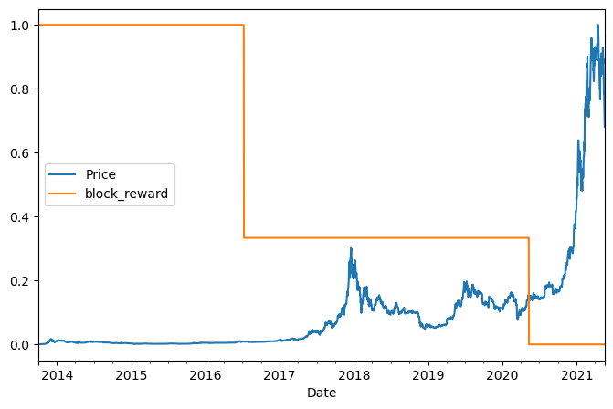

```python
plot_time_series_multivar(bitcoin_prices_block)
```

### **4.3. Pre-processing**

```python
# Setup dataset hyperparameters
horizon = 1
window_size = 7
```

#### Train/Test Split

```python
train_data, val_data, train_time, test_time = train_test_split_multivar(bitcoin_prices_block, 0.8)
len(train_data), len(val_data), len(train_time), len(test_time)
```

```
(2229, 558, 2229, 558)
```

```python
train_data[:3], train_time[:3]
```

```
(array([[123.65,  25.  ],
        [125.45,  25.  ],
        [108.58,  25.  ]]),
 DatetimeIndex(['2013-10-01', '2013-10-02', '2013-10-03'], dtype='datetime64[ns]', name='Date', freq=None))
```

#### Windowing

```python
train_dataset = windowed_dataset_multivar(train_data.astype(np.float32),window_size, G.BATCH_SIZE, 1000)
val_dataset = windowed_dataset_multivar(val_data.astype(np.float32), window_size, G.BATCH_SIZE, 1000, False)
```

### **4.4. Model 7 - Dense Multivariate**

#### Build, compile and fit the model

```python
num_features = train_data.shape[1]
num_features
```

```
2
```

```python
def build_compile_model_6(name, window_size=window_size, horizon=horizon, num_features=num_features, dropout_rate=0.1):

    model = tf.keras.models.Sequential([
        tf.keras.layers.Dense(128, activation='relu', input_shape=(window_size, num_features)),
                    # input_shape should match your features
        tf.keras.layers.Dense(64, activation='relu'),
        tf.keras.layers.Flatten(),
        tf.keras.layers.Dense(horizon)
    ], name=name)

    model.compile(
            loss='mse',
            optimizer=tf.keras.optimizers.Adam(learning_rate=1e-4),
            metrics=['mae','mse']
    )

    return model


model_6 = build_compile_model_6('Dense_Model_Multivariate')
model_6.summary()
```

```
Model: "Dense_Model_Multivariate"
_________________________________________________________________
 Layer (type)                Output Shape              Param #
=================================================================
 dense_177 (Dense)           (None, 7, 128)            384

 dense_178 (Dense)           (None, 7, 64)             8256

 flatten_7 (Flatten)         (None, 448)               0

 dense_179 (Dense)           (None, 1)                 449

=================================================================
Total params: 9089 (35.50 KB)
Trainable params: 9089 (35.50 KB)
Non-trainable params: 0 (0.00 Byte)
_________________________________________________________________
```

```python
# fit
history_6 = model_6.fit(
    train_dataset,
    epochs=50,
    verbose=0,
    validation_data=val_dataset,
    callbacks=[early_stop])
```

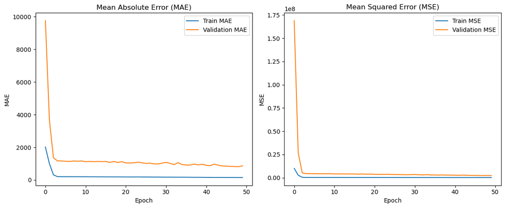

```python
plot_history_multivar(history_6)
```

#### Forecasting

Let's make a few predictions.

```python
# Set global print options to display 2 decimal places
np.set_printoptions(precision=2, suppress=True)
```

```python
# first, let's choose an initial window
for x, _ in val_dataset.take(-1):
    initial_window = x.numpy()[-1]

initial_window, initial_window.shape
```

```
(array([[55715.55,     6.25],
        [56573.55,     6.25],
        [52147.82,     6.25],
        [49764.13,     6.25],
        [50032.69,     6.25],
        [47885.62,     6.25],
        [45604.62,     6.25]], dtype=float32),
 (7, 2))
```

```python
make_forecast_multivar(model_6, initial_window, 3, verbose=True)
```

```
Predicting on:
 [[55715.55     6.25]
 [56573.55     6.25]
 [52147.82     6.25]
 [49764.13     6.25]
 [50032.69     6.25]
 [47885.62     6.25]
 [45604.62     6.25]] -> Prediction: 48161.390625

Predicting on:
 [[56573.55     6.25]
 [52147.82     6.25]
 [49764.13     6.25]
 [50032.69     6.25]
 [47885.62     6.25]
 [45604.62     6.25]
 [48161.39     6.25]] -> Prediction: 48018.33984375

Predicting on:
 [[52147.82     6.25]
 [49764.13     6.25]
 [50032.69     6.25]
 [47885.62     6.25]
 [45604.62     6.25]
 [48161.39     6.25]
 [48018.34     6.25]] -> Prediction: 47862.64453125
```

```
array([48161.39, 48018.34, 47862.64], dtype=float32)
```

We can see that it keeps the second value fixed (we only predict the bitcoin price).

#### Evaluation

First, before evaluating, we're going to get the true values from the validation dataset (which is batched and not shuffled). These values correspond to the data from index window_size + 1 up to (window_size + 1) + num_samples.

```python
# First 12 values of the ds

num_to_print = 12
count = 0

for x_batch, y_batch in val_dataset:
    for y in y_batch.numpy():
        print(y)
        count += 1
        if count >= num_to_print:
            break
    if count >= num_to_print:
        break
```

```
8656.971
8500.644
8469.261
8537.34
8205.807
8118.489
8074.8433
7612.7407
7262.1104
7303.406
7041.733
7211.862
```

```python
def get_first_n_samples(dataset, n):
    x_list = []
    y_list = []
    count = 0

    for x_batch, y_batch in dataset:
        for x, y in zip(x_batch, y_batch):
            x_list.append(x)
            y_list.append(y)
            count += 1
            if count >= n:
                return tf.stack(x_list), tf.stack(y_list)

    return tf.stack(x_list), tf.stack(y_list)  # in case n > total samples

def get_true_future_labels(dataset, window_size, steps_ahead):
    _, y = get_first_n_samples(dataset, window_size + steps_ahead)
    return y[window_size:]  # skip the initial window
```

```python
aux = get_true_future_labels(val_dataset, window_size, 5)
aux
```

```
<tf.Tensor: shape=(5,), dtype=float32, numpy=array([7612.74, 7262.11, 7303.41, 7041.73, 7211.86], dtype=float32)>
```

Now, let's evaluate:

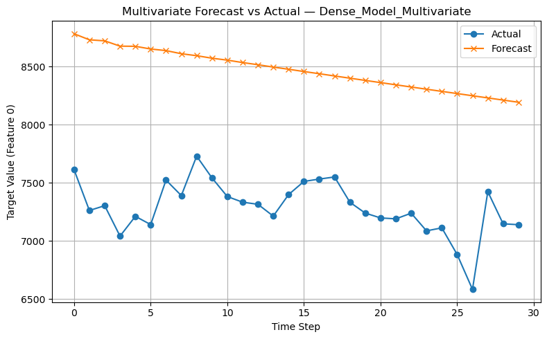

```python
# Step 1: Get initial window from first batch
for x_batch, y_batch in val_dataset.take(1):
    initial_window = x_batch[0].numpy()  # shape: (WINDOW_SIZE, num_features)
    break


# true values to compare
true_future = get_true_future_labels(val_dataset, window_size, forecast_horizon)


# Forecast and evaluate
forecast_multivar_1, results_multivar_1 = pred_eval_multivar(
    model=model_6,
    initial_window=initial_window,
    test_labels=true_future,
    X_test=None,
    validation_steps=forecast_horizon
)
```

```python
results_multivar_1
```

```
{'mae': 1183.3364, 'mse': 1446346.0, 'rmse': 1202.6412, 'mape': 16.324648}
```

#### Analysis

| Metric | Value | Interpretation |
| --- | --- | --- |
| **MAE** | 1,183 | Average error over **$1,180**, indicating significant deviations from actual values. |
| **RMSE** | 1,203 | RMSE slightly higher than MAE → some larger errors are present. |
| **MAPE** | 16.3% | Predictions are off by **over 16% on average** — showing moderate but insufficient accuracy. |

Adding the feature (block reward) did not improve results for this simple dense model, suggesting it may not add predictive value in this setup.

## **5. Result comparison**

```python
results = {
    'Dense 1 (WS: 7)': results_1,
    'Dense 2 (WS: 30)': results_2,
    'Conv1D': results_3,
    'LSTM': results_4,
    'Ensemble': ensemble_results,
    'Dense - MV': results_multivar_1
}

df_results = pd.DataFrame(results).T  # transpose to have models as rows
print(df_results)
```

```
                          mae           mse         rmse       mape      mase
Dense 1 (WS: 7)    377.743713  2.437752e+05   493.735962   5.151052  2.520879
Dense 2 (WS: 30)   713.842102  7.845989e+05   885.775879   9.688037  5.059377
Conv1D             608.903442  5.207871e+05   721.655762   8.140013  3.848976
LSTM               353.355865  1.822436e+05   426.899994   4.838035  2.024417
Ensemble           346.469391  2.158080e+05   464.551453   4.637511  2.190088
Dense - MV        1183.336426  1.446346e+06  1202.641235  16.324648       NaN
```

```python
df_results.style.highlight_min(axis=0, color='lightgreen') # min
```

|  | mae | mse | rmse | mape | mase |
| --- | --- | --- | --- | --- | --- |
| Dense 1 (WS: 7) | 377.743713 | 243775.203125 | 493.735962 | 5.151052 | 2.520879 |
| Dense 2 (WS: 30) | 713.842102 | 784598.875000 | 885.775879 | 9.688037 | 5.059377 |
| Conv1D | 608.903442 | 520787.062500 | 721.655762 | 8.140013 | 3.848976 |
| LSTM | 353.355865 | 182243.593750 | 426.899994 | 4.838035 | 2.024417 |
| Ensemble | 346.469391 | 215808.046875 | 464.551453 | 4.637511 | 2.190088 |
| Dense - MV | 1183.336426 | 1446346.000000 | 1202.641235 | 16.324648 | nan |

#### Plots

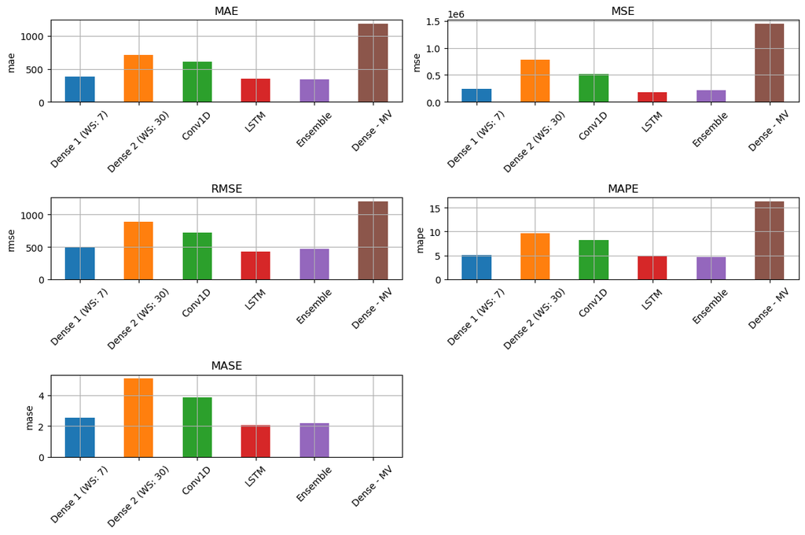

```python
# Step 3: Plot each metric in a separate subplot
metrics = df_results.columns
n_metrics = len(metrics)

fig, axes = plt.subplots(nrows=(n_metrics + 1) // 2, ncols=2, figsize=(12, 8))
axes = axes.flatten()

for i, metric in enumerate(metrics):
    df_results[metric].plot(kind='bar', ax=axes[i], title=metric.upper(), color=plt.cm.tab10.colors )
    axes[i].set_ylabel(metric)
    axes[i].grid(True)
    axes[i].set_xticklabels(df_results.index, rotation=45)

# Remove empty subplot if odd number of metrics
if len(axes) > n_metrics:
    fig.delaxes(axes[-1])

plt.tight_layout()
plt.show()
```

#### Analysis

[output not shown]

- The Ensemble confirms that combining multiple models (even if trained with few epochs) can boost performance.
- The LSTM is the strongest standalone model, likely due to its ability to capture sequential patterns.
- Dense 1 performs decently with a small window, but performance drops sharply in Dense 2 with a larger window.
- Conv1D offers moderate performance but doesn’t outperform simpler models.
- The Dense - MV model (with the added feature) underperforms badly, suggesting that the block reward feature may be irrelevant or poorly integrated in this simple setup.

Ensemble learning and temporal models (like LSTM) are promising. Further tuning and better feature engineering could lead to even stronger models.

## **6. References**

[DeepLearning.AI TensorFlow Developer Professional Certificate](https://www.coursera.org/learn/tensorflow-sequences-time-series-and-prediction?specialization=tensorflow-in-practice)

[TensorFlow for Deep Learning Bootcamp](https://www.udemy.com/course/tensorflow-developer-certificate-machine-learning-zero-to-mastery/?couponCode=MTST7102224B2)